# task - course4, week2

```python
from plotly.offline import init_notebook_mode
init_notebook_mode()
```

```python
import plotly.graph_objs as go
```

```python
import matplotlib.pyplot as plt
```

```python
import os
import pandas as pd
pd.set_option('display.max_columns', 100)
pd.set_option('display.max_rows', 100)
```

```python
path_to_data = "data"
```

```python
data = pd.read_csv(os.path.join(path_to_data, "CompleteDataset.csv"), low_memory=False, index_col=0)
data.head()
```

|  | Name | Age | Photo | Nationality | Flag | Overall | Potential | Club | Club Logo | Value | Wage | Special | Acceleration | Aggression | Agility | Balance | Ball control | Composure | Crossing | Curve | Dribbling | Finishing | Free kick accuracy | GK diving | GK handling | GK kicking | GK positioning | GK reflexes | Heading accuracy | … |
| --- | --- | --- | --- | --- | --- | --- | --- | --- | --- | --- | --- | --- | --- | --- | --- | --- | --- | --- | --- | --- | --- | --- | --- | --- | --- | --- | --- | --- | --- | --- |
| 0 | Cristiano Ronaldo | 32 | https://cdn.sofifa.org/48/18/players/20801.png | Portugal | https://cdn.sofifa.org/flags/38.png | 94 | 94 | Real Madrid CF | https://cdn.sofifa.org/24/18/teams/243.png | €95.5M | €565K | 2228 | 89 | 63 | 89 | 63 | 93 | 95 | 85 | 81 | 91 | 94 | 76 | 7 | 11 | 15 | 14 | 11 | 88 | … |
| 1 | L. Messi | 30 | https://cdn.sofifa.org/48/18/players/158023.png | Argentina | https://cdn.sofifa.org/flags/52.png | 93 | 93 | FC Barcelona | https://cdn.sofifa.org/24/18/teams/241.png | €105M | €565K | 2154 | 92 | 48 | 90 | 95 | 95 | 96 | 77 | 89 | 97 | 95 | 90 | 6 | 11 | 15 | 14 | 8 | 71 | … |
| 2 | Neymar | 25 | https://cdn.sofifa.org/48/18/players/190871.png | Brazil | https://cdn.sofifa.org/flags/54.png | 92 | 94 | Paris Saint-Germain | https://cdn.sofifa.org/24/18/teams/73.png | €123M | €280K | 2100 | 94 | 56 | 96 | 82 | 95 | 92 | 75 | 81 | 96 | 89 | 84 | 9 | 9 | 15 | 15 | 11 | 62 | … |
| 3 | L. Suárez | 30 | https://cdn.sofifa.org/48/18/players/176580.png | Uruguay | https://cdn.sofifa.org/flags/60.png | 92 | 92 | FC Barcelona | https://cdn.sofifa.org/24/18/teams/241.png | €97M | €510K | 2291 | 88 | 78 | 86 | 60 | 91 | 83 | 77 | 86 | 86 | 94 | 84 | 27 | 25 | 31 | 33 | 37 | 77 | … |
| 4 | M. Neuer | 31 | https://cdn.sofifa.org/48/18/players/167495.png | Germany | https://cdn.sofifa.org/flags/21.png | 92 | 92 | FC Bayern Munich | https://cdn.sofifa.org/24/18/teams/21.png | €61M | €230K | 1493 | 58 | 29 | 52 | 35 | 48 | 70 | 15 | 14 | 30 | 13 | 11 | 91 | 90 | 95 | 91 | 89 | 25 | … |

```python
data.tail()
```

|  | Name | Age | Photo | Nationality | Flag | Overall | Potential | Club | Club Logo | Value | Wage | Special | Acceleration | Aggression | Agility | Balance | Ball control | Composure | Crossing | Curve | Dribbling | Finishing | Free kick accuracy | GK diving | GK handling | GK kicking | GK positioning | GK reflexes | Heading accuracy | … |
| --- | --- | --- | --- | --- | --- | --- | --- | --- | --- | --- | --- | --- | --- | --- | --- | --- | --- | --- | --- | --- | --- | --- | --- | --- | --- | --- | --- | --- | --- | --- |
| 17976 | A. Kelsey | 17 | https://cdn.sofifa.org/48/18/players/237463.png | England | https://cdn.sofifa.org/flags/14.png | 46 | 63 | Scunthorpe United | https://cdn.sofifa.org/24/18/teams/1949.png | €50K | €1K | 755 | 24 | 16 | 38 | 26 | 12 | 23 | 14 | 13 | 12 | 5 | 12 | 46 | 47 | 49 | 42 | 48 | 10 | … |
| 17977 | B. Richardson | 47 | https://cdn.sofifa.org/48/18/players/11728.png | England | https://cdn.sofifa.org/flags/14.png | 46 | 46 | Wycombe Wanderers | https://cdn.sofifa.org/24/18/teams/1933.png | €0 | €1K | 832 | 25 | 44 | 35 | 44 | 22 | 44 | 11 | 12 | 11 | 11 | 11 | 39 | 50 | 39 | 50 | 37 | 12 | … |
| 17978 | J. Young | 17 | https://cdn.sofifa.org/48/18/players/231381.png | Scotland | https://cdn.sofifa.org/flags/42.png | 46 | 61 | Swindon Town | https://cdn.sofifa.org/24/18/teams/1934.png | €60K | €1K | 1194 | 66 | 26 | 60 | 77 | 41 | 50 | 28 | 32 | 37 | 47 | 25 | 11 | 15 | 12 | 12 | 11 | 47 | … |
| 17979 | J. Lundstram | 18 | https://cdn.sofifa.org/48/18/players/238813.png | England | https://cdn.sofifa.org/flags/14.png | 46 | 64 | Crewe Alexandra | https://cdn.sofifa.org/24/18/teams/121.png | €60K | €1K | 1302 | 57 | 46 | 58 | 74 | 43 | 45 | 34 | 30 | 41 | 32 | 34 | 10 | 13 | 7 | 8 | 9 | 40 | … |
| 17980 | L. Sackey | 18 | https://cdn.sofifa.org/48/18/players/238308.png | Ghana | https://cdn.sofifa.org/flags/117.png | 46 | 64 | Scunthorpe United | https://cdn.sofifa.org/24/18/teams/1949.png | €50K | €1K | 1031 | 48 | 52 | 49 | 47 | 32 | 33 | 19 | 17 | 23 | 20 | 17 | 15 | 8 | 10 | 10 | 7 | 48 | … |

```python
data.shape
```

```
(17981, 74)
```

# matplotlib

## Гистограмма возраста игроков

Гистограмма возраста укажет на доминирующий возраст и особенности распределения

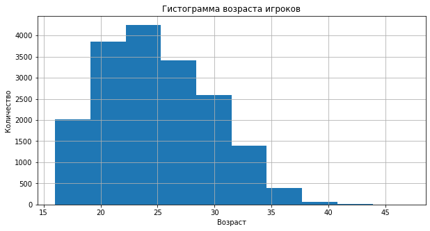

```python
data.Age.hist(figsize=(10, 5))
plt.xlabel("Возраст")
plt.ylabel("Количество")
plt.title("Гистограмма возраста игроков");
```

#### Описание:

- доминирующий возраст - 23-25 лет
- встречаются игроки и за 40

## Зависимость средней зарплаты от возраста игроков

График укажет, в каком возрасте игроки в среднем наиболее оплачиваемые и как меняется средняя зарплата с возрастом

```python
# Переведем формат зарплаты в число, отбросив первый и последний (если надо) символ и преобразовав тип
data["Wage_value"] = data["Wage"].apply(lambda s: s[1:-1] if s[-1] == "K" else s[1:]).astype(float)
```

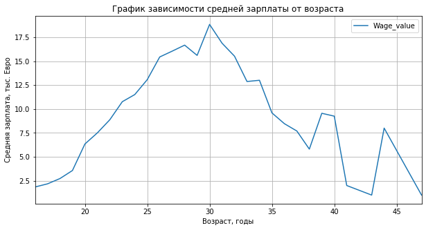

```python
# сгруппируем по годам и усредним
age_wage = data.groupby("Age")["Wage_value"].mean()

age_wage.plot(figsize=(10, 5))
plt.grid()
plt.xlabel("Возраст, годы")
plt.ylabel("Средняя зарплата, тыс. Евро")
plt.legend()
plt.title("График зависимости средней зарплаты от возраста");
```

## Максимальная зарплата по годам

Добавим максимальную зарплату. Посмотрим на график зависимости от возраста, а также на сколько отличается максимальная зарплата от средней

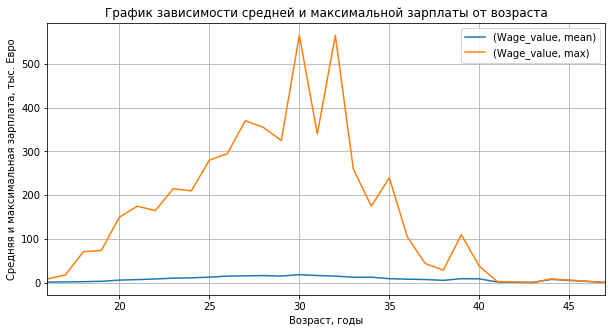

```python
# сгруппируем по годам и возьмем среднее и макс
age_wage = data.groupby("Age").agg({"Wage_value": ["mean", "max"]})

age_wage.plot(figsize=(10, 5))
plt.grid()
plt.xlabel("Возраст, годы")
plt.ylabel("Средняя и максимальная зарплата, тыс. Евро")
plt.legend()
plt.title("График зависимости средней и максимальной зарплаты от возраста");
```

#### Описание:

- разница между средней и максимальной зарплатой в возрасте 25-35 лет - огромна, примерно 2 порядка
- после 40 максимальная и средняя практически сравниваются

# Plotly

## Топ-10 стран, из которых игроки наиболее востребованы

Бар-график укажет на наиболее востребованную страну, из которой играют игроки и десятку топовых стран по этой характеристике

```python
top10_natio = data.groupby("Nationality")["Name"].count().sort_values(ascending=False).head(10)
top10_natio
```

```
Nationality
England        1630
Germany        1140
Spain          1019
France          978
Argentina       965
Brazil          812
Italy           799
Colombia        592
Japan           469
Netherlands     429
Name: Name, dtype: int64
```

```python
trace1 = go.Bar(
    x=top10_natio.index, y=top10_natio,
    text=top10_natio.index,
)

layout = go.Layout(
    title = 'Топ 10 наиболее востребованных стран, из которых играют футболисты',
    xaxis = {"title":'Страна'},
    yaxis = {"title": "Число игроков из страны"},
)

fig = go.Figure(data=[trace1], layout=layout)
fig.show()
```

[interactive chart not shown]

#### Описание:

- наиболее востребованы игроки из Англии, причем их числоскачкообразно больше ближайшей Германии, далее разрывы более плавны
- в десятку неожиданно (для меня) попала Япония, причем даже опередив Нидерланды

## Наиболее оплачиваемые игровые позиции

Бар-график укажет наиболее оплачиваемые позиции на поле и их соотношение

```python
top10_positions_wage = data.groupby(["Preferred Positions"])["Wage_value"].mean().sort_values(ascending=False)[:10]
top10_positions_wage
```

```
Preferred Positions
ST CAM RW CF     190.0
LW LM RM CAM     175.0
RW RM CM         140.0
RM LW ST LM      138.0
RWB RM ST        120.0
LM RM RWB        115.0
RW CM RM CAM     105.0
RW LW CM         100.0
RW LM LW RM       95.0
CF LW ST RW       95.0
Name: Wage_value, dtype: float64
```

```python
trace1 = go.Bar(
    x=top10_positions_wage.index, y=top10_positions_wage,
    text=top10_positions_wage.index,
    marker=dict(
        color=top10_positions_wage, #set color equal to a variable
        colorscale='Viridis', # one of plotly colorscales
        showscale=True
    )
)

layout = go.Layout(
    title = 'Топ 10 наиболее оплачиваемых позиций на поле',
    xaxis = {"title":'Позиция'},
    yaxis = {"title": "Средняя зарплата на позиции, тыс. Евро"}
)

fig = go.Figure(data=[trace1], layout=layout)
fig.show()
```

[interactive chart not shown]

#### Описание:

- средняя максимальная зарплата на позиции - 190 тыс. евро и это ST CAM RW CF
- убывание оплаты по позициям в топе достаточно плавное

## График востребовательности агрессивной игры

График укажет, являются ли наиболее агрессивные игроки также и наиболее оплачиваемыми. А также проиллюстрирует, есть ли вообще видимая корреляция между агрессивной манерой игры и зарплатой

```python
data_sorted_100 = data.sort_values("Wage_value", ascending=False)[:100]
```

```python
trace1 = go.Scatter(
    x=data_sorted_100["Aggression"],
    y=data_sorted_100["Wage_value"],
    text=data_sorted_100["Name"],
    mode='markers',
    marker=dict(
        size=data_sorted_100["Wage_value"]/data_sorted_100["Wage_value"].max()*20,
        color=top10_positions_wage, #set color equal to a variable
        colorscale='Viridis', # one of plotly colorscales
        showscale=True
    )
)

layout = go.Layout(
    title = 'Зависимость между зарплатой и агрессивностью игры',
    xaxis = {"title":'Показатель агрессии'},
    yaxis = {"title": "Средняя зарплата на позиции, тыс. Евро"}
)

fig = go.Figure(data=[trace1], layout=layout)
fig.show()
```

[interactive chart not shown]

#### Описание:

- видимой корреляции между агрессивной манерой игры и оплатой игроков не наблюдается